# datavis_ggplot2

Jeroen Claes

11/4/2021

# Data visualisatie met ggplot2

Welkom op het video kanaal van CROPLAND. Mijn naam is Jeroen Claes en ik ben een data scientist bij CROPLAND. In een eerdere video hebben we getoond hoe je zelf de data achter deze grafiek kan maken. In dit filmpje ga ik je tonen hoe je de grafiek zelf maakt. Voor je begint, kijk dus zeker even terug naar onze vorige post om er zeker van te zijn dat je kan starten van de juiste data.

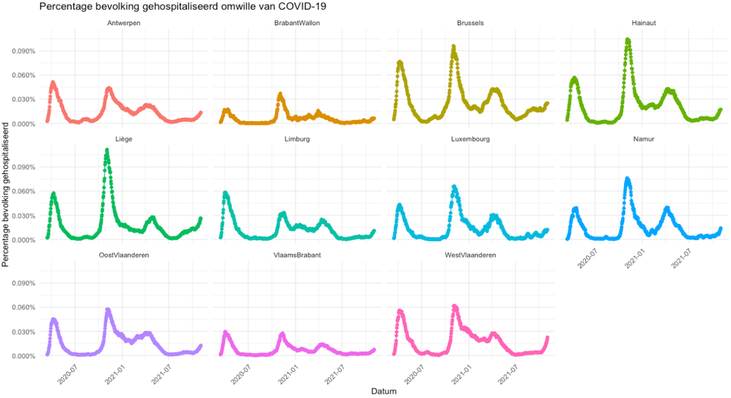

## Packages

Laten we starten met een aantal packages in te laden. We beginnen met ggplot2, het meest gebruikte pakket voor data-visualisatie met R. Verder laden we ook nog het scales pakket in. Dit pakket zal ons toelaten om de labels van de assen van onze grafiek mooi vorm te geven. Ten slotte laden we ook het dplyr pakket, omdat dit onder andere de glimpse functie bevat om snel een kijkje te nemen naar de data

```r
library(ggplot2)
library(scales)
library(dplyr)
```

## Data

Laten we nu even kijken hoe onze data er ook alweer uitziet. Dit kan met de dplyr functie glimpse. We kunnen zien dat de data georganiseerd is per datum. Voor elke datum hebben we het aantal gehospitaliseerden per provincie. In ons eerder filmpje hebben we aan de provincies de bevolkingsaantallen toegevoegd. Met deze extra informatie hebben we dan een nieuwe variabele toegevoegd, namelijk het percentage van de bevolking die gehospitaliseerd is omwille van COVID.

```r
glimpse(covid)
```

```
## Rows: 6,611
## Columns: 5
## $ DATE                                    <date> 2020-03-15, 2020-03-15, 2020-…
## $ PROVINCE                                <chr> "Antwerpen", "Brussels", "Hain…
## $ TOTAL_IN                                <dbl> 50, 58, 54, 20, 22, 4, 2, 16, …
## $ MS_POPULATION                           <dbl> 1875524, 1219970, 1345947, 880…
## $ `Percentage bevolking gehospitaliseerd` <dbl> 2.665922e-05, 4.754215e-05, 4.…
```